# Live Session Assignment 6

Chris Irwin

10/15/2016

Please load the following packages (plyr, gdata)

After downloading the Excel file and saving it as a .csv file run the following command

```r
qns <- read.csv("rollingsales_Queens.csv",skip=4,header=TRUE)
```

We need to remove commas from the data set, we will create a new column named Sale.Price.N

```r
qns$SALE.PRICE.N <- as.numeric(gsub("[^[:digit:]]","", qns$SALE.PRICE))
```

See the number of records that have an NA after removing commas

```r
count(is.na(qns$SALE.PRICE.N))
```

```
##       x  freq
## 1 FALSE 17924
## 2  TRUE  7875
```

We are renaming the variables names to be all lower case

```r
names(qns) <- tolower(names(qns))
head(qns)
```

```
##   borough              neighborhood
## 1       4 AIRPORT JFK
## 2       4 AIRPORT LA GUARDIA
## 3       4 AIRPORT LA GUARDIA
## 4       4 AIRPORT LA GUARDIA
## 5       4 AIRPORT LA GUARDIA
## 6       4 AIRPORT LA GUARDIA
##                        building.class.category tax.class.at.present block
## 1 31  COMMERCIAL VACANT LAND                                      4 14260
## 2 01  ONE FAMILY DWELLINGS                                        1   976
## 3 01  ONE FAMILY DWELLINGS                                        1   976
## 4 02  TWO FAMILY DWELLINGS                                        1   976
## 5 03  THREE FAMILY DWELLINGS                                      1   949
## 6 03  THREE FAMILY DWELLINGS                                      1   949
##   lot ease.ment building.class.at.present
```

[output cut: 34 more lines]

Remove additional commas in columns gross.sqft, land.sqft

```r
qns$gross.sqft <- as.numeric(gsub("[^[:digit:]]","", qns$gross.square.feet))
qns$land.sqft <- as.numeric(gsub("[^[:digit:]]","", qns$land.square.feet))
```

Cast year.built as numeric

```r
qns$year.built <- as.numeric(as.character(qns$year.built))
```

Look at price data to see if there are any outliers

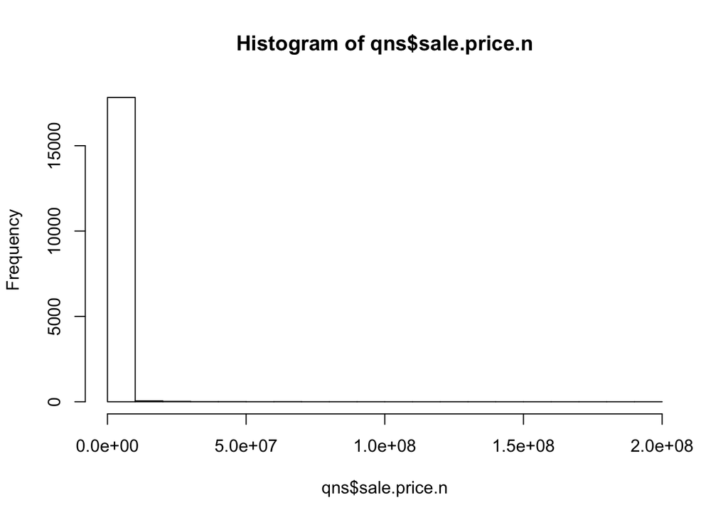

```r
hist(qns$sale.price.n)
```

```r
qns.sale <- qns[qns$sale.price.n!=0,]
dim(qns.sale)
```

```
## [1] 25799    24
```

Create a plot to show Gross SQ Ft vs Sales Price

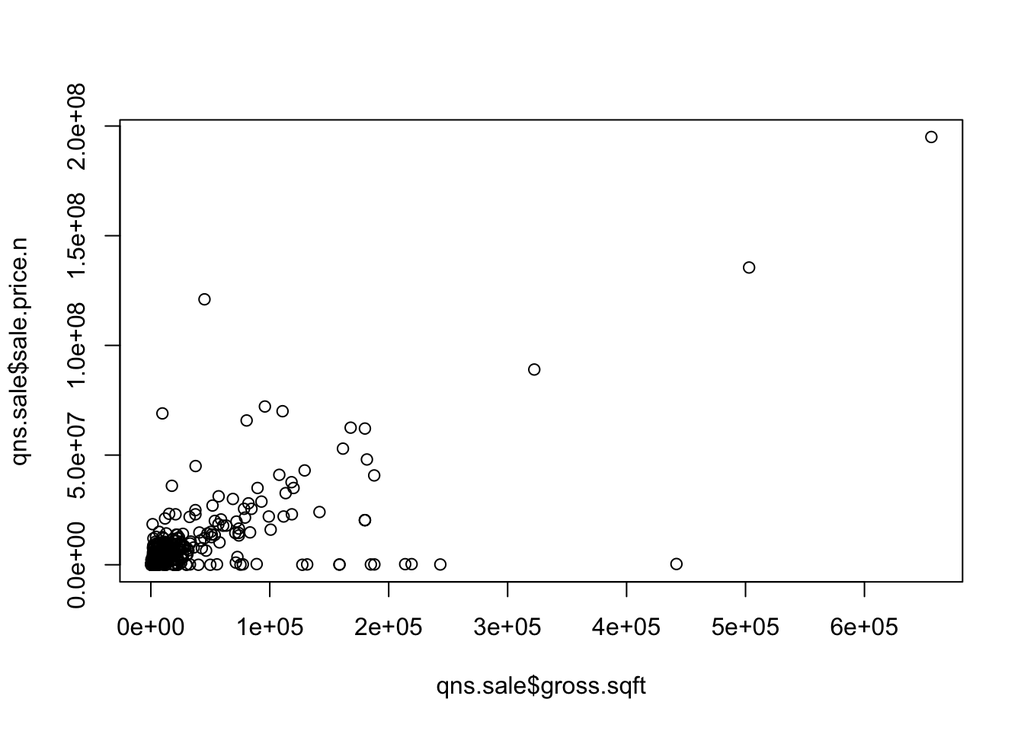

```r
plot(qns.sale$gross.sqft,qns.sale$sale.price.n)
```

Due to the extreme outliers we can try a log transformation

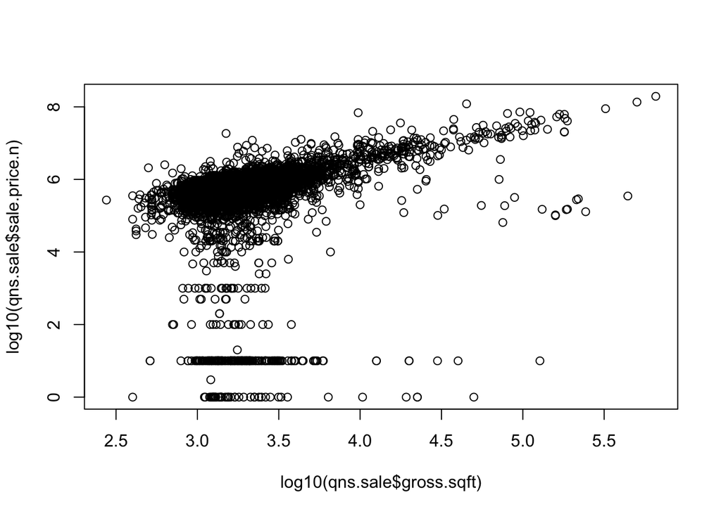

```r
plot(log10(qns.sale$gross.sqft),log10(qns.sale$sale.price.n))
```

Now we want to look at 1, 2 and 3 family homes

```r
qns.homes <- qns.sale[which(grepl("FAMILY",qns.sale$building.class.category)),]
dim(qns.homes)
```

```
## [1] 10105    24
```

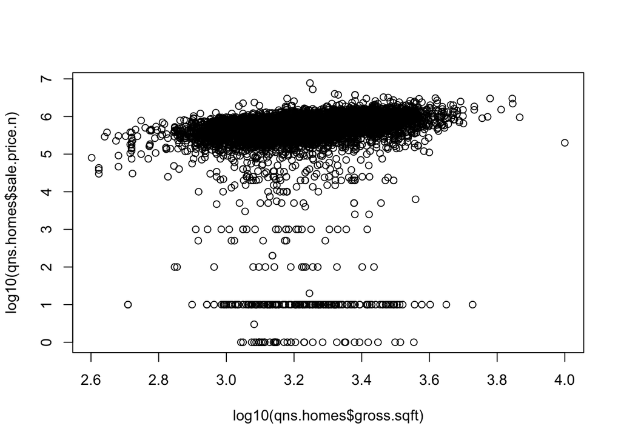

```r
plot(log10(qns.homes$gross.sqft),log10(qns.homes$sale.price.n))
```

Take a look at the summary for sales prices of family homes lower than 100,000.00

```r
summary(qns.homes[which(qns.homes$sale.price.n<100000),])
```

```
##     borough                     neighborhood
##  Min.   :4   SOUTH JAMAICA            : 27
##  1st Qu.:4   ST. ALBANS               : 25
##  Median :4   HOLLIS                   : 20
##  Mean   :4   SO. JAMAICA-BAISLEY PARK : 20
##  3rd Qu.:4   RICHMOND HILL            : 18
##  Max.   :4   SOUTH OZONE PARK         : 17
##              (Other)                  :291
##                                  building.class.category
##  01  ONE FAMILY DWELLINGS                    :243
##  02  TWO FAMILY DWELLINGS                    :152
##  03  THREE FAMILY DWELLINGS                  : 23
##  04  TAX CLASS 1 CONDOS                      :  0
##  05  TAX CLASS 1 VACANT LAND                 :  0
##  06  TAX CLASS 1 - OTHER                     :  0
##  (Other)                                     :  0
##  tax.class.at.present     block            lot          ease.ment
##  1      :418          Min.   :  155   Min.   :   1.00   Mode:logical
##         :  0          1st Qu.: 6725   1st Qu.:  18.00   NA's:418
##  1A     :  0          Median :10186   Median :  37.00
##  1B     :  0          Mean   : 9441   Mean   :  65.26
##  1C     :  0          3rd Qu.:12473   3rd Qu.:  67.75
##  2      :  0          Max.   :16268   Max.   :1510.00
##  (Other):  0
##  building.class.at.present                                      address
##  A1     :110               107-33 156TH STREET                      :  3
##  B3     : 63               106-35 96TH   STREET                     :  2
##  A5     : 50               117-39 142ND   PLACE                     :  2
##  B2     : 43               219 BEACH 91ST STREET                    :  2
##  A2     : 40               248-46 88TH DRIVE                        :  2
##  B1     : 31               317 BEACH 13 STREET                      :  2
##  (Other): 81               (Other)                                  :405
##      apartment.number    zip.code     residential.units commercial.units
##              :418     Min.   :11001   Min.   :1.000     Min.   :0.00000
##  1           :  0     1st Qu.:11375   1st Qu.:1.000     1st Qu.:0.00000
##  1-A         :  0     Median :11418   Median :1.000     Median :0.00000
##  1-C         :  0     Mean   :11425   Mean   :1.474     Mean   :0.02153
##  1.00E+02    :  0     3rd Qu.:11433   3rd Qu.:2.000     3rd Qu.:0.00000
##  10          :  0     Max.   :11694   Max.   :3.000     Max.   :1.00000
##  (Other)     :  0
```

[output cut: 9 more lines]

```
##  Min.   :1                 A1     :110                     10     :169
##  1st Qu.:1                 B3     : 63                     1      : 37
##  Median :1                 A5     : 50                     1,000  : 21
##  Mean   :1                 B2     : 43                     20,000 : 17
##  3rd Qu.:1                 A2     : 40                     100    : 16
##  Max.   :1                 B1     : 31                     25,000 : 13
##                            (Other): 81                    (Other) :145
##    sale.date    sale.price.n     gross.sqft     land.sqft
##  1/28/16:  6   Min.   :    1   Min.   : 400   Min.   :  613
##  3/7/16 :  6   1st Qu.:   10   1st Qu.:1216   1st Qu.: 2017
##  2/22/16:  5   Median :  100   Median :1511   Median : 2672
##  3/1/16 :  5   Mean   :15724   Mean   :1666   Mean   : 3036
##  3/17/16:  5   3rd Qu.:24000   3rd Qu.:2003   3rd Qu.: 4000
##  4/21/16:  5   Max.   :95000   Max.   :5341   Max.   :10293
##  (Other):386
```

We want to remove any outliers that look like they werent actual sales. We created a new column called outliers by using the log of 10.

```r
qns.homes$outliers <- (log10(qns.homes$sale.price.n) <=5) + 0
```

Now we want to remove the outliers and only use properties that are sales by recreating the qns.homes data set.

```r
qns.homes <- qns.homes[which(qns.homes$outliers==0),]
```

Final Tidy data set

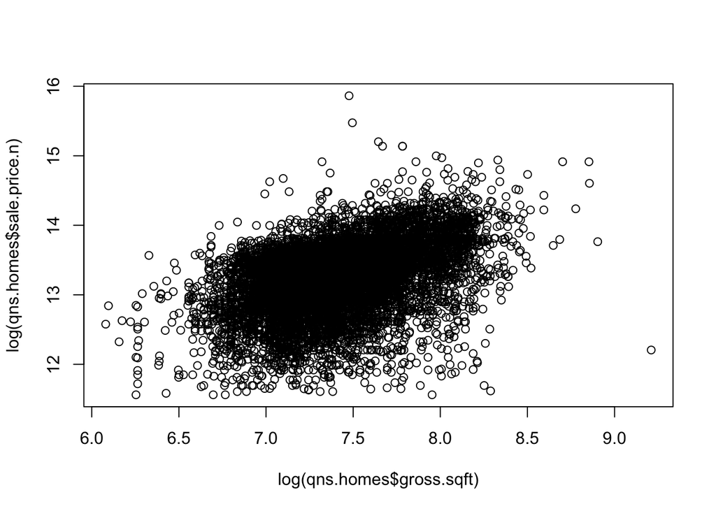

```r
plot(log(qns.homes$gross.sqft),log(qns.homes$sale.price.n))
```

```r
library(plotly)
library(sqldf)
average.PricePerHood <- sqldf('select neighborhood, avg([sale.price.n]) as AverageOfHood from [qns.homes] group by neighborhood order by neighborhood')

 plot_ly(x = average.PricePerHood$neighborhood, y= average.PricePerHood$AverageOfHood, Name = "Average Price per Neighborhood", type = "bar")
```

[interactive chart not shown]